# RSA Explanations

Erin Bennett

There are several components to an explanation:

- Actual State
  - observable variables (input, output)
  - latent variables (structural parameters, unobservable states)
- Counterfactual Prior over Programs
  - structural parameters
  - alternative inputs
- Listener
  - knowledge about observable variables
  - knowledge about latent variables
- Speaker
  - alternative utterances (and their associated costs)
  - question under discussion (utility function)
  - knowledge about actual state
- Literal
  - a semantics for “because”
    - (e.g. are the components entailed? presupposed?)

We did a replication and extension of Lucas and Kemp (2015)’s counterfactual experiments. We asked people to rate explanations, e.g. “A was present because B was present.”

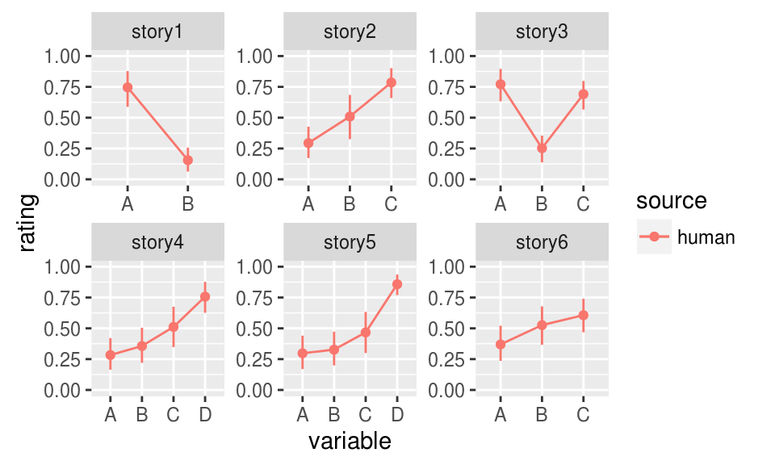

We implement a model (CF.DIFF) where the speaker/explainer chooses the explanans that maximizes the counterfactual *change* in the explanandum.

The items where this model diverges from people’s intutions *seem* to be ones in which the explanation communicates something about the causal **structure** (e.g. B is or is not directly causally downstream of A).

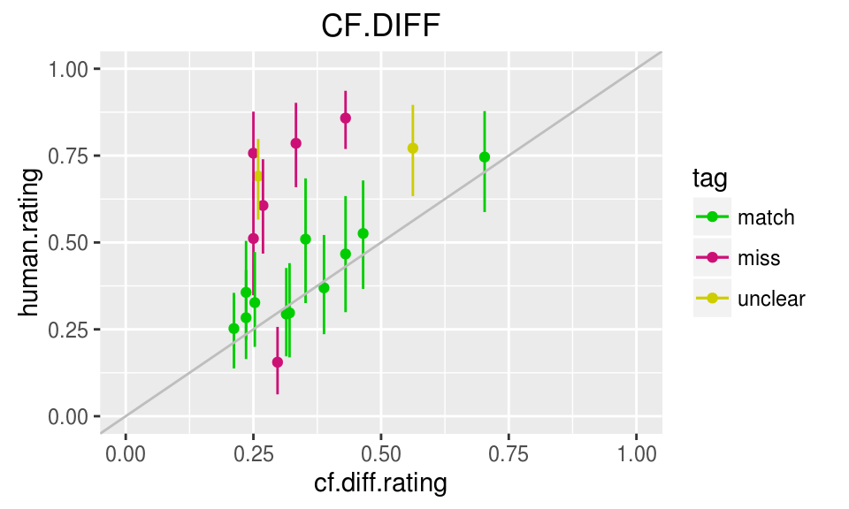

We implement a second model (RSA.BASE) where there are no structural parameters, there *are* alternative possible inputs, the speaker knows all of the actual input and output values, and the listener knows none of them.

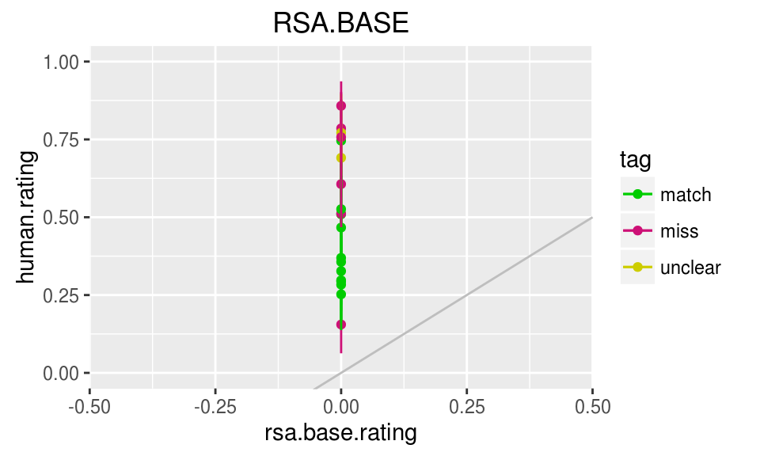

# References

Lucas, Christopher G, and Charles Kemp. 2015. “An Improved Probabilistic Account of Counterfactual Reasoning.” *Psychological Review* 122 (4). American Psychological Association: 700.